# causal-jobs

```
Automatically generated in: 2026-09-14
```

This is the latest weekly report containing, as always, information on the status of causal inference in the European job market. It is based on accumulated information starting early May 2022. Latest vacancies, the rate of relevant job postings, most "causal" companies and other info can be found here.

*Disclaimer:* This report is automatically created by acessing daily job alert emails and retrieving the relevant information through an ETL pipeline. There are days when the number of new job postings exceeds a threshold (6 as of February 2023), and not every causal-job is contained in the email this app feeds on. As a result, some causal-jobs might never make it into the pipeline, meaning that the database I have created is by no means complete. However, this doesn't happen too often, and info listed in the report can serve as a solid indication on the status of causal inference in the European job market.

Code can be found at https://github.com/ggiannarakis/causal-jobs

## What are the latest jobs?

The list of jobs that included "causal inference" in their description in the EU for the past 7 days.

[output not shown]

## New kids on the block?

Are any of the above companies listing "causal inference" in the job description for the first time?

```
Nope. All companies seen above have posted causal-jobs before!
```

## Retrospective analysis

### How many causal-jobs did appear in each email?

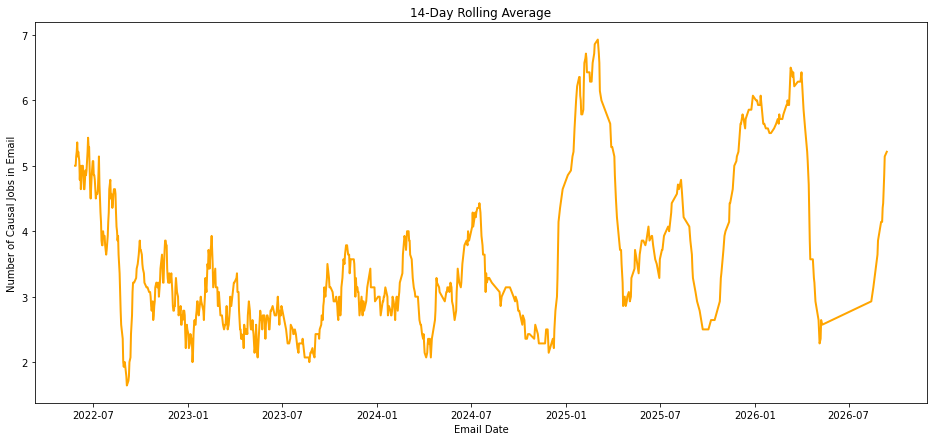

### What is the total number of distinct causal-jobs since May 2022?

A distinct causal-job is defined as a unique job title - company name pair. Since companies may hire for the same job title in different time periods, below number is conservative and its growth is expected to slow down as the "causal namespace" is gradually exhausted.

```
There were 1432 unique causal jobs detected so far in the EU!
```

```
This amounts to approximately 6 unique causal jobs per week.
```

### And what about the most "causal" companies?

Below are the top 5 companies in terms of distinct causal jobs published.

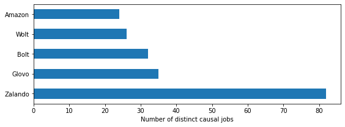

### The causal wordcloud

A worldcloud out of all job titles indexed in the database. It seems like "causal inference" and "data scientist" are a match made in heaven!

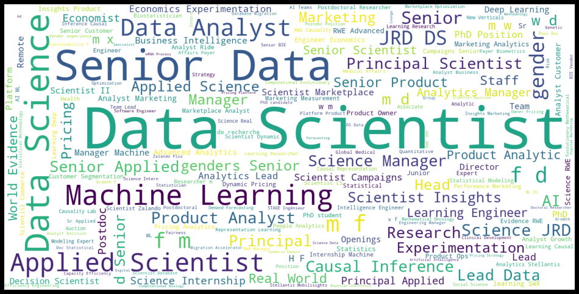